# Dataset & Exploration

Jie Yu

2019-03-26

```r
knitr::opts_chunk$set(
  collapse = TRUE,
  message = F,
  warning = F
  )

library(tidyverse)
library(readxl)
library(stringr)
```

### Generate resulting dataset

First, make a catalogue

```r
catalogue =  read_excel("./data/CHSI_DataSet.xlsx", sheet = "DATAELEMENTDESCRIPTION") %>%
  janitor::clean_names() %>%
  # pick out "County data"
  mutate(county_data = ifelse(str_detect(.$description, c("[Cc]ounty data")) == TRUE, 1, 0)) %>%
  filter(county_data == 1) %>%
  # select the categories of variables which we want to use
  filter(page_name %in% c("Demographics", "SummaryMeasuresOfHealth", "RiskFactorsAndAccessToCare", "VunerablePopsAndEnvHealth")) %>%
  filter(
    !str_detect(column_name, c("^Ecol")),
    !str_detect(column_name, c("^Salm")),
    !str_detect(column_name, c("^Shig")),
    !str_detect(column_name, c("^Toxic"))
  )
```

Select variables from different datasets based on our catalogue

```r
demographics = read.csv("./data/Demographics.csv")

# select columns from the dataframe based on variables from another dataframe
tbl_1 = read.csv("./data/Demographics.csv") %>%
  select(one_of(dput(as.character(catalogue$column_name))))
## c("Population_Size", "Population_Density", "Poverty", "Age_19_Under",
## "Age_19_64", "Age_65_84", "Age_85_and_Over", "White", "Black",
## "Native_American", "Asian", "Hispanic", "ALE", "All_Death", "Health_Status",
## "Unhealthy_Days", "No_HS_Diploma", "Unemployed", "Sev_Work_Disabled",
## "Major_Depression", "Recent_Drug_Use", "No_Exercise", "Few_Fruit_Veg",
## "Obesity", "High_Blood_Pres", "Smoker", "Diabetes", "Uninsured",
## "Elderly_Medicare", "Disabled_Medicare", "Prim_Care_Phys_Rate",
## "Dentist_Rate")

tbl_2 = read.csv("./data/SummaryMeasuresOfHealth.csv") %>%
  select(one_of(dput(as.character(catalogue$column_name))))
## c("Population_Size", "Population_Density", "Poverty", "Age_19_Under",
## "Age_19_64", "Age_65_84", "Age_85_and_Over", "White", "Black",
## "Native_American", "Asian", "Hispanic", "ALE", "All_Death", "Health_Status",
## "Unhealthy_Days", "No_HS_Diploma", "Unemployed", "Sev_Work_Disabled",
## "Major_Depression", "Recent_Drug_Use", "No_Exercise", "Few_Fruit_Veg",
## "Obesity", "High_Blood_Pres", "Smoker", "Diabetes", "Uninsured",
## "Elderly_Medicare", "Disabled_Medicare", "Prim_Care_Phys_Rate",
## "Dentist_Rate")

tbl_3 = read.csv("./data/RiskFactorsAndAccessToCare.csv") %>%
  select(one_of(dput(as.character(catalogue$column_name))))
## c("Population_Size", "Population_Density", "Poverty", "Age_19_Under",
## "Age_19_64", "Age_65_84", "Age_85_and_Over", "White", "Black",
## "Native_American", "Asian", "Hispanic", "ALE", "All_Death", "Health_Status",
## "Unhealthy_Days", "No_HS_Diploma", "Unemployed", "Sev_Work_Disabled",
## "Major_Depression", "Recent_Drug_Use", "No_Exercise", "Few_Fruit_Veg",
## "Obesity", "High_Blood_Pres", "Smoker", "Diabetes", "Uninsured",
## "Elderly_Medicare", "Disabled_Medicare", "Prim_Care_Phys_Rate",
## "Dentist_Rate")

tbl_4 = read.csv("./data/VunerablePopsAndEnvHealth.csv") %>%
  select(one_of(dput(as.character(catalogue$column_name))))
## c("Population_Size", "Population_Density", "Poverty", "Age_19_Under",
## "Age_19_64", "Age_65_84", "Age_85_and_Over", "White", "Black",
## "Native_American", "Asian", "Hispanic", "ALE", "All_Death", "Health_Status",
## "Unhealthy_Days", "No_HS_Diploma", "Unemployed", "Sev_Work_Disabled",
## "Major_Depression", "Recent_Drug_Use", "No_Exercise", "Few_Fruit_Veg",
## "Obesity", "High_Blood_Pres", "Smoker", "Diabetes", "Uninsured",
## "Elderly_Medicare", "Disabled_Medicare", "Prim_Care_Phys_Rate",
## "Dentist_Rate")

data = cbind(tbl_1, tbl_2, tbl_3, tbl_4)

# add identifiers
data = cbind(demographics$CHSI_County_Name, demographics$CHSI_State_Abbr, data) %>%
  rename(county_name = 'demographics$CHSI_County_Name',
         state_abbr = 'demographics$CHSI_State_Abbr') %>%
  janitor::clean_names() %>%
  # Take out the response 'ale'
  select(ale, everything())
```

Look at our resulting dataset:

```r
names(data)
```

```
##  [1] "ale"                 "county_name"         "state_abbr"
##  [4] "population_size"     "population_density"  "poverty"
##  [7] "age_19_under"        "age_19_64"           "age_65_84"
## [10] "age_85_and_over"     "white"               "black"
## [13] "native_american"     "asian"               "hispanic"
## [16] "all_death"           "health_status"       "unhealthy_days"
## [19] "no_exercise"         "few_fruit_veg"       "obesity"
## [22] "high_blood_pres"     "smoker"              "diabetes"
## [25] "uninsured"           "elderly_medicare"    "disabled_medicare"
## [28] "prim_care_phys_rate" "dentist_rate"        "no_hs_diploma"
## [31] "unemployed"          "sev_work_disabled"   "major_depression"
## [34] "recent_drug_use"
```

```r
skimr::skim(data)
## Skim summary statistics
##  n obs: 3141
##  n variables: 34
##
## ── Variable type:factor ──────────────────────────────────────────────────────────────────────────────────────────────
##     variable missing complete    n n_unique
##  county_name       0     3141 3141     1847
##   state_abbr       0     3141 3141       51
##                          top_counts ordered
##  Was: 32, Jef: 26, Fra: 25, Jac: 24   FALSE
##  TX: 254, GA: 159, VA: 134, KY: 120   FALSE
##
## ── Variable type:integer ─────────────────────────────────────────────────────────────────────────────────────────────
##            variable missing complete    n     mean        sd    p0   p25
##   disabled_medicare       0     3141 3141  1858.45   4698.55 -2222   275
##    elderly_medicare       0     3141 3141 10878.69  31387.57 -2222  1607
##    major_depression       0     3141 3141  5431.82  16322.35     4   673
##       no_hs_diploma       0     3141 3141 12045.47  47612.55 -2222  1768
##  population_density       0     3141 3141   249.12   1703.04 -2222    17
##     population_size       0     3141 3141 94368.16 306431.66    62 11211
##     recent_drug_use       0     3141 3141  5323.73  18738.55     2   548
##   sev_work_disabled       0     3141 3141  2936.91  27873.81 -2222   297
##          unemployed       0     3141 3141  2382.29   8031.45 -9999   287
##           uninsured       0     3141 3141 12644.81  54604.78 -2222  1549
##    p50   p75    p100     hist
##    690  1667  118190 ▇▁▁▁▁▁▁▁
##   3448  8053  911590 ▇▁▁▁▁▁▁▁
##   1562  3880   5e+05 ▇▁▁▁▁▁▁▁
##   4106  8955 1872316 ▇▁▁▁▁▁▁▁
##     44   109   69390 ▇▁▁▁▁▁▁▁
##  25235 64040 9935475 ▇▁▁▁▁▁▁▁
##   1319  3573  665392 ▇▁▁▁▁▁▁▁
##    736  1850 1474332 ▇▁▁▁▁▁▁▁
##    669  1671  256472 ▇▁▁▁▁▁▁▁
##   3426  8116 2167891 ▇▁▁▁▁▁▁▁
##
## ── Variable type:numeric ─────────────────────────────────────────────────────────────────────────────────────────────
##             variable missing complete    n    mean     sd      p0     p25
##            age_19_64       0     3141 3141   60.29   3.36    47.6    58.3
##         age_19_under       0     3141 3141   24.81   3.28     1.4    22.7
##            age_65_84       0     3141 3141   12.79   3.33     2.1    10.7
##      age_85_and_over       0     3141 3141    2.12   0.95     0.1     1.5
##                  ale       0     3141 3141   74.86  58.03 -2222.2    75
##            all_death       0     3141 3141  903.4  151.48 -2222.2   814
##                asian       0     3141 3141    1.12   2.76     0       0.3
##                black       0     3141 3141    8.99  14.55     0       0.5
##         dentist_rate       0     3141 3141   31.45  45.61 -2222.2    18.7
##             diabetes       0     3141 3141 -142.52 381.65 -1111.1     5
##        few_fruit_veg       0     3141 3141 -389.74 581.55 -1111.1 -1111.1
##        health_status       0     3141 3141 -221.23 460.84 -1111.1     8.9
##      high_blood_pres       0     3141 3141 -559.87 568.62 -1111.1 -1111.1
##             hispanic       0     3141 3141    7.02  12.46     0       1.1
##      native_american       0     3141 3141    1.97   7.68     0       0.2
##          no_exercise       0     3141 3141 -312.13 520.27 -1111.1 -1111.1
##              obesity       0     3141 3141 -307.28 516.25 -1111.1 -1111.1
##              poverty       0     3141 3141   12.64  40.19 -2222.2     9.8
##  prim_care_phys_rate       0     3141 3141   57.56  44.79     0      30.5
##               smoker       0     3141 3141 -292.49 508.39 -1111.1 -1111.1
##       unhealthy_days       0     3141 3141 -187.74 423.14 -1111.1     4.5
##                white       0     3141 3141   87.02  16.15     4.7    82.8
##      p50   p75   p100     hist
##     60.3  62.3   83.3 ▁▂▇▆▁▁▁▁
##     24.6  26.4   47.2 ▁▁▁▇▇▁▁▁
##     12.5  14.7   29.2 ▁▂▇▇▃▁▁▁
##      1.9   2.6    7.6 ▂▇▆▂▁▁▁▁
##     76.5  77.7   81.3 ▁▁▁▁▁▁▁▇
##    898.5 989.8 1869.6 ▁▁▁▁▁▅▇▁
##      0.5   1     55.9 ▇▁▁▁▁▁▁▁
##      2.1  10.3   86   ▇▁▁▁▁▁▁▁
##     30    43.3  377.9 ▁▁▁▁▁▁▇▁
##      7     9.1   20.8 ▁▁▁▁▁▁▁▇
##     74    80.2   96.4 ▅▁▁▁▁▁▁▇
##     14.6  19.4   47.7 ▂▁▁▁▁▁▁▇
##  -1111.1  26.1   47.1 ▇▁▁▁▁▁▁▇
##      2.3   6.3   97.5 ▇▁▁▁▁▁▁▁
##      0.4   0.9   93.4 ▇▁▁▁▁▁▁▁
##     22.6  28.6   52.4 ▃▁▁▁▁▁▁▇
##     21.7  25.8   42.6 ▃▁▁▁▁▁▁▇
##     12.6  16.2   36.2 ▁▁▁▁▁▁▁▇
##     50.6  74.7  581.2 ▇▂▁▁▁▁▁▁
##     20.3  25.1   46.2 ▃▁▁▁▁▁▁▇
##      5.7   6.6   12.6 ▂▁▁▁▁▁▁▇
##     94.1  97.6  100   ▁▁▁▁▁▁▂▇
```

```r
write.csv(data, file = "./data/data.csv")
```

### Deal with Missing Data

```r
data.try = data

# List of missing value (see `CHSI_DataSet.csv)
list = c(-9999, -2222, -2222.2, -2, -1111.1, -1111, -1)

for (i in 1:length(list)) {
  data.try[ data.try == list[i] ] <- NA
}

# Re-check
sapply(data.try[1:ncol(data.try)], function(x) {list %in% x}) %>%
  sum() # all the missing values have been re-written as NA
```

```
## [1] 0
```

```r
# See: which variables have NA
sapply(data.try[1:ncol(data.try)], function(x) sum(length(which(is.na(x)))))
```

```
##                 ale         county_name          state_abbr
##                   2                   0                   0
##     population_size  population_density             poverty
##                   0                   1                   1
##        age_19_under           age_19_64           age_65_84
##                   0                   0                   0
##     age_85_and_over               white               black
##                   0                   0                   0
##     native_american               asian            hispanic
##                   0                   0                   0
##           all_death       health_status      unhealthy_days
##                   3                 664                 545
##         no_exercise       few_fruit_veg             obesity
##                 935                1237                 917
##     high_blood_pres              smoker            diabetes
##                1619                 874                 422
##           uninsured    elderly_medicare   disabled_medicare
##                   3                  31                  32
## prim_care_phys_rate        dentist_rate       no_hs_diploma
##                   0                   1                   1
##          unemployed   sev_work_disabled    major_depression
##                   8                  28                   0
##     recent_drug_use
##                   0
```

```r
percentage_NA <- sapply(data.try[1:ncol(data.try)], function(x) sum(length(which(is.na(x)))) / nrow(data.try) * 100)

percentage_NA
```

```
##                 ale         county_name          state_abbr
##          0.06367399          0.00000000          0.00000000
##     population_size  population_density             poverty
##          0.00000000          0.03183699          0.03183699
##        age_19_under           age_19_64           age_65_84
##          0.00000000          0.00000000          0.00000000
##     age_85_and_over               white               black
##          0.00000000          0.00000000          0.00000000
##     native_american               asian            hispanic
##          0.00000000          0.00000000          0.00000000
##           all_death       health_status      unhealthy_days
##          0.09551098         21.13976441         17.35116205
##         no_exercise       few_fruit_veg             obesity
##         29.76758994         39.38236230         29.19452404
##     high_blood_pres              smoker            diabetes
##         51.54409424         27.82553327         13.43521172
##           uninsured    elderly_medicare   disabled_medicare
##          0.09551098          0.98694683          1.01878383
## prim_care_phys_rate        dentist_rate       no_hs_diploma
##          0.00000000          0.03183699          0.03183699
##          unemployed   sev_work_disabled    major_depression
##          0.25469596          0.89143585          0.00000000
##     recent_drug_use
##          0.00000000
```

Extract all the variables with NA -> data.NA

```r
for (i in 1:length(percentage_NA)) {
    if (percentage_NA[i] > 0) {
         print(percentage_NA[i]) # value with name
    }
}
```

```
##        ale
## 0.06367399
## population_density
##         0.03183699
##    poverty
## 0.03183699
##  all_death
## 0.09551098
## health_status
##      21.13976
## unhealthy_days
##       17.35116
## no_exercise
##    29.76759
## few_fruit_veg
##      39.38236
##  obesity
## 29.19452
## high_blood_pres
##        51.54409
##   smoker
## 27.82553
## diabetes
## 13.43521
##  uninsured
## 0.09551098
## elderly_medicare
##        0.9869468
## disabled_medicare
##          1.018784
## dentist_rate
##   0.03183699
## no_hs_diploma
##    0.03183699
## unemployed
##   0.254696
## sev_work_disabled
##         0.8914358
```

```r
list_NA <- percentage_NA[which(percentage_NA > 0)] %>%
  names()

data.NA = data.try %>%
  select(one_of(dput(as.character(list_NA))))
## c("ale", "population_density", "poverty", "all_death", "health_status",
## "unhealthy_days", "no_exercise", "few_fruit_veg", "obesity",
## "high_blood_pres", "smoker", "diabetes", "uninsured", "elderly_medicare",
## "disabled_medicare", "dentist_rate", "no_hs_diploma", "unemployed",
## "sev_work_disabled")
```

Check if there are percentage_NA > 30%

```r
# method 1
percentage_NA[which(percentage_NA > 30)]
```

```
##   few_fruit_veg high_blood_pres
##        39.38236        51.54409
```

```r
# method 2
for (i in 1:length(percentage_NA)) {
    if (percentage_NA[i] > 30) {
        print(percentage_NA[i]) # value with name
    }
}
## few_fruit_veg
##      39.38236
## high_blood_pres
##        51.54409
```

`few_fruit_veg` and `high_blood_pres` has missing data > 30%, so we drop them.

```r
data.NA = data.NA %>%
  select(-few_fruit_veg, -high_blood_pres )

data.try = data.try %>%
  select(-few_fruit_veg, -high_blood_pres )
```

Draw the histograms for all the variables with NA:

```r
data.NA %>% gather() %>% head()
```

```
##   key value
## 1 ale  74.9
## 2 ale  76.6
## 3 ale  74.5
## 4 ale  73.2
## 5 ale  76.1
## 6 ale  71.9
```

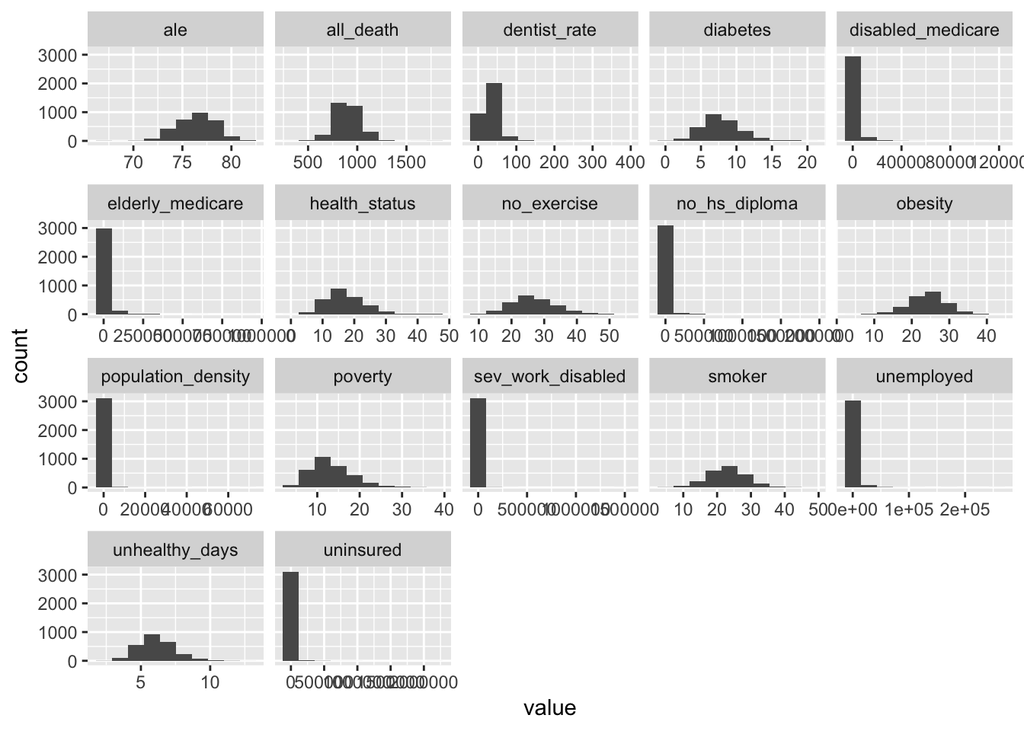

```r
# subset(data, !is.na(variable)): Eliminating NAs from a ggplot
ggplot(subset(gather(data.NA), !is.na(value)), aes(value)) +
    geom_histogram(bins = 10) +
    facet_wrap(~key, scales = 'free_x')
```

Approximately normal: ale, all_death, diabetes, health_status, no_exercise, obesity, poverty, smoker, unhealth_days

Mean imputation for these approximately normal variables:

```r
normal_list <- c('ale', 'all_death', 'diabetes', 'health_status', 'no_exercise', 'obesity', 'poverty', 'smoker', 'unhealthy_days')

normal_dataset = data.NA %>%
  select(one_of(dput(as.character(normal_list))))
## c("ale", "all_death", "diabetes", "health_status", "no_exercise",
## "obesity", "poverty", "smoker", "unhealthy_days")

for(i in 1:ncol(normal_dataset)){
  normal_dataset[is.na(normal_dataset[,i]), i] <- mean(normal_dataset[,i], na.rm = TRUE)
}

# Check
sum(is.na(normal_dataset)) # no NA
```

```
## [1] 0
```

Median imputation for other skewed variables:

```r
# L[!(L %in% L1)]
skew_list <- names(data.NA)[!(names(data.NA) %in% normal_list)]
skew_list
```

```
## [1] "population_density" "uninsured"          "elderly_medicare"
## [4] "disabled_medicare"  "dentist_rate"       "no_hs_diploma"
## [7] "unemployed"         "sev_work_disabled"
```

```r
skew_dataset = data.NA %>%
  select(one_of(dput(as.character(skew_list))))
## c("population_density", "uninsured", "elderly_medicare", "disabled_medicare",
## "dentist_rate", "no_hs_diploma", "unemployed", "sev_work_disabled"
## )

for(i in 1:ncol(skew_dataset)){
  skew_dataset[is.na(skew_dataset[,i]), i] <- median(skew_dataset[,i], na.rm = TRUE)
}

# Check
sum(is.na(skew_dataset)) # no NA
```

```
## [1] 0
```

Generating resulting dataset with no NAs: `dataset`

```r
no_NA_list <- names(data.try)[!(names(data.try) %in% names(data.NA))]
no_NA_list
```

```
##  [1] "county_name"         "state_abbr"          "population_size"
##  [4] "age_19_under"        "age_19_64"           "age_65_84"
##  [7] "age_85_and_over"     "white"               "black"
## [10] "native_american"     "asian"               "hispanic"
## [13] "prim_care_phys_rate" "major_depression"    "recent_drug_use"
```

```r
no_NA_dataset = data.try %>%
  select(one_of(dput(as.character(no_NA_list))))
## c("county_name", "state_abbr", "population_size", "age_19_under",
## "age_19_64", "age_65_84", "age_85_and_over", "white", "black",
## "native_american", "asian", "hispanic", "prim_care_phys_rate",
## "major_depression", "recent_drug_use")

dataset = cbind(no_NA_dataset, normal_dataset, skew_dataset)
```

### Correlation plot

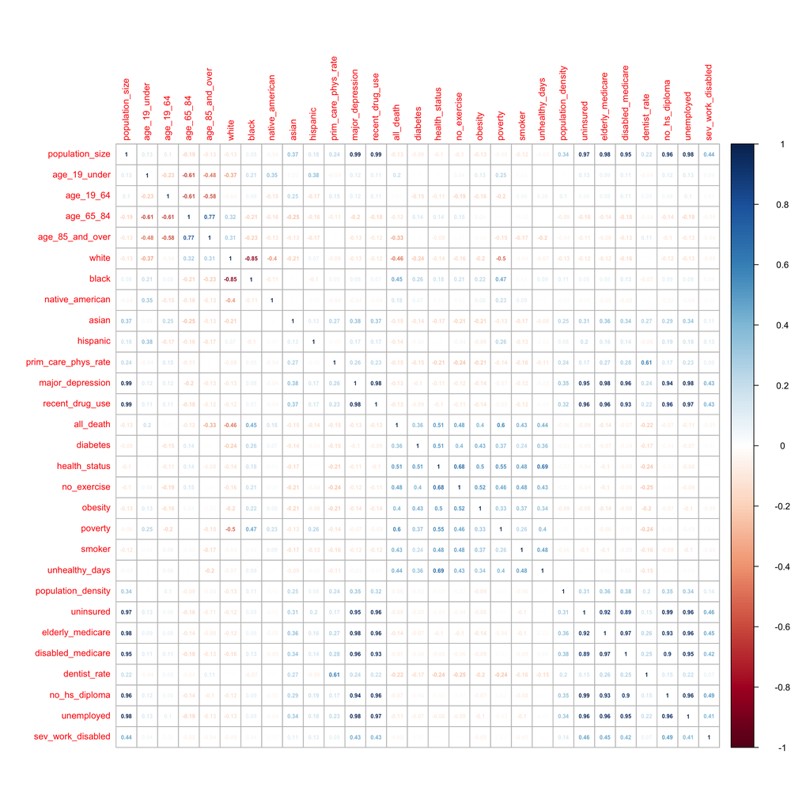

```r
library(corrplot)

dataset_1 = dataset %>%
  select(-county_name, -state_abbr)

x = model.matrix(ale ~., dataset_1)[,-1]
corrplot(cor(x), method = "number", number.cex = 0.5, tl.cex = 0.8)
```

## PCA Analysis for Variable Selection

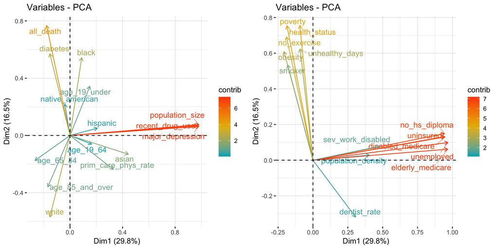

```r
library(factoextra)
library(patchwork)
#Scale and perform pca (take out non-continuous vars & response)
dataset.pca <- dataset %>%
  select(-county_name, -state_abbr, -ale) %>%
  scale() %>%
  as.data.frame() %>%
  prcomp()

name.vec <- dataset %>% select(-county_name, -state_abbr, -ale) %>% names()

pca.viz1 <- fviz_pca_var(dataset.pca,
             col.var = "contrib",
             gradient.cols = c("#00AFBB", "#E7B800", "#FC4E07"),
             repel = TRUE,
             select.var = list(name = name.vec[1:15]))

pca.viz2 <- fviz_pca_var(dataset.pca,
             col.var = "contrib",
             gradient.cols = c("#00AFBB", "#E7B800", "#FC4E07"),
             repel = TRUE,
             select.var = list(name = name.vec[16:29]))

pca.viz1 + pca.viz2
```

```r
dataset = dataset %>%
  select(-c(age_19_64, age_65_84, age_19_under),
         -c(hispanic, native_american, asian, black)
         )
```

Here I have dropped some age variables and race variables. We need to decide which to keep among `population_size`, `major_depression`, `recent_drug_use`, `uninsured`, `elderly_medicare`, `disabled_medicare`, `no_hs_diploma`, `unemployed`.

Divide by population_size:

```r
dataset.try2 = dataset %>%
  mutate(
    major_depression2 = major_depression / population_size,
    recent_drug_use2 = recent_drug_use / population_size,
    uninsured2 = uninsured / population_size,
    elderly_medicare2 = elderly_medicare / population_size,
    disabled_medicare2 = disabled_medicare / population_size,
    no_hs_diploma2 = no_hs_diploma / population_size,
    unemployed2 =  unemployed / population_size,
    sev_work_disabled2 = sev_work_disabled / population_size
    ) %>%
  select(-c(major_depression, recent_drug_use, uninsured, elderly_medicare, disabled_medicare, no_hs_diploma, unemployed, sev_work_disabled))
```

check correlation again:

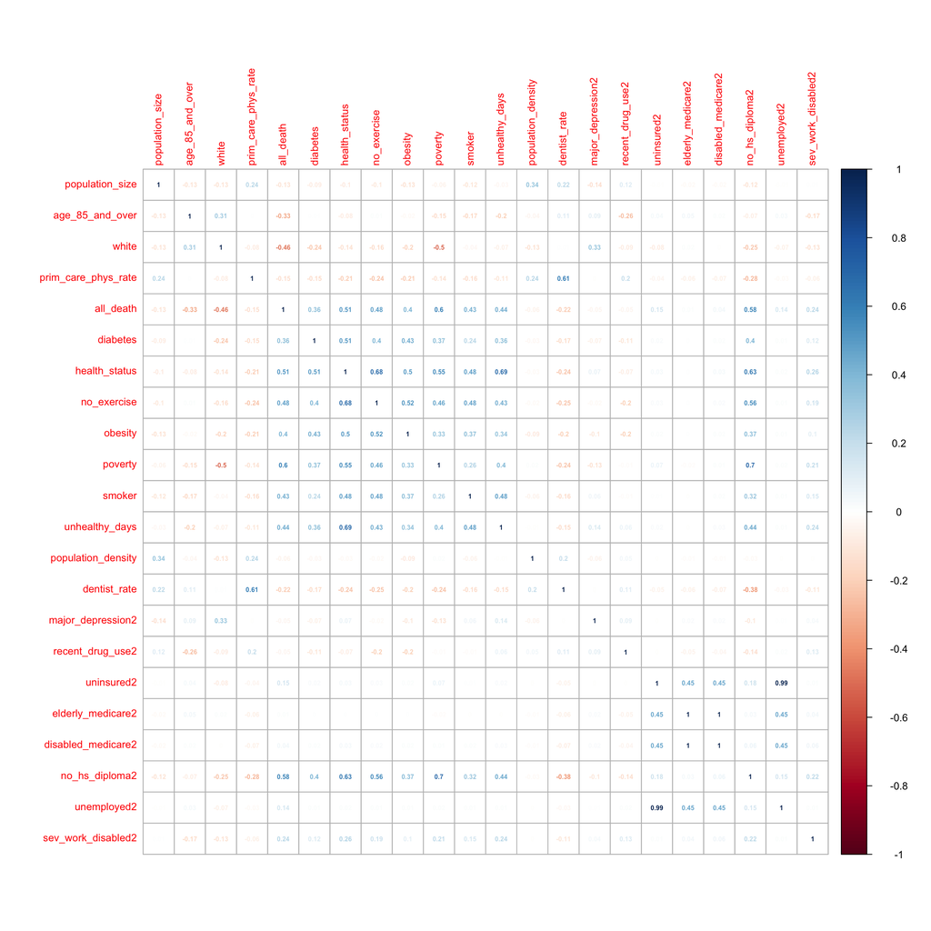

```r
dataset.try2_1 = dataset.try2 %>%
  select(-county_name, -state_abbr)

x = model.matrix(ale ~., dataset.try2_1)[,-1]
corrplot(cor(x), method = "number", number.cex = 0.5, tl.cex = 0.8)
```

Great! Successfully eliminate most of the correlation!

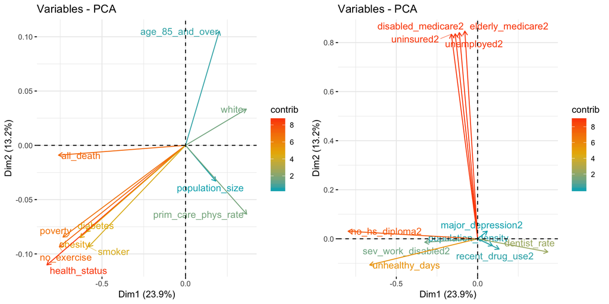

```r
dataset.try2.pca <- dataset.try2 %>%
  select(-county_name, -state_abbr, -ale) %>%
  scale() %>%
  as.data.frame() %>%
  prcomp()

name.vec <- dataset.try2 %>%
  select(-county_name, -state_abbr, -ale) %>%
  names()

pca.viz1 <- fviz_pca_var(dataset.try2.pca,
             col.var = "contrib",
             gradient.cols = c("#00AFBB", "#E7B800", "#FC4E07"),
             repel = TRUE,
             select.var = list(name = name.vec[1:11]))

pca.viz2 <- fviz_pca_var(dataset.try2.pca,
             col.var = "contrib",
             gradient.cols = c("#00AFBB", "#E7B800", "#FC4E07"),
             repel = TRUE,
             select.var = list(name = name.vec[12:22]))

pca.viz1 + pca.viz2
```

Magnitude are very close.

Need to decide which to drop from `unemployed2` and `uninsured2`.

Let’s keep `uninsured2` because that’s the more directly health-related variable.

Final Dataset: `dataset.final`

```r
dataset.final = dataset.try2 %>%
  select(-unemployed2)

names(dataset.final)
```

```
##  [1] "county_name"         "state_abbr"          "population_size"
##  [4] "age_85_and_over"     "white"               "prim_care_phys_rate"
##  [7] "ale"                 "all_death"           "diabetes"
## [10] "health_status"       "no_exercise"         "obesity"
## [13] "poverty"             "smoker"              "unhealthy_days"
## [16] "population_density"  "dentist_rate"        "major_depression2"
## [19] "recent_drug_use2"    "uninsured2"          "elderly_medicare2"
## [22] "disabled_medicare2"  "no_hs_diploma2"      "sev_work_disabled2"
```

```r
write.csv(dataset.final, file = "./data/dataset.final.csv")
```